# Exercise 3 - Updated

## Question 4 Local Polynomial

#### Part A

$$g_x(x_i,a)=a_0+\sum_{k=1}^D a_k(x-x_i)^k$$
where $a=\{a_0,a_1,,,,,a_D\}$
$$\hat{a}=argmin \sum_i^n w_i (y_i-g_x(x_i,a))^2$$
Define matrix $R$ and $W$
$$R=\left[\begin{array}{ccccc}
1 &(x_1-x)^{1} &(x_1-x)^{2} &... & (x_1-x)^{D} \\
1 &(x_2-x)^{1} &(x_2-x)^{2} &... & (x_2-x)^{D} \\
... &... &... &... &... \\
1 &(x_n-x)^{1} &(x_n-x)^{2} &... & (x_n-x)^{D} \\
\end{array}
\right]$$

$$W=\left[\begin{array}{ccccc}
w_1 &0 &0 &... & 0 \\
0 &w2 &0 &... & 0 \\
... &... &... &... &... \\
0 &0 &0 &... & w_n \\
\end{array}
\right]$$
Then,
$$a=argmin (y-Ra)^T W (y-Ra)$$
Take the derivative w.r.t to $a$ and set to $0$
$$\frac{\partial(y-Ra)^T W (y-Ra) }{\partial a}=-2R^Twy+2R^TwRa=0$$
gives us
$$\hat{a}= (R^T W R)^{-1} R^T W y$$

And $\hat{f(x)}=g(x,a)=a_0=e_1^T (R^TWR)^{-1}R^TWy$

#### Part B

When $p=1$,
$$R=\left[\begin{array}{cc}
1 &(x_1-x) \\
1 &(x_2-x) \\
... &... \\
1 &(x_n-x) \\
\end{array}
\right]$$
$$W=\left[\begin{array}{ccccc}
K(\frac{x_1-x}{h}) &0 &0 &... & 0 \\
0 &K(\frac{x_2-x}{h}) &0 &... & 0 \\
... &... &... &... &... \\
0 &0 &0 &... & K(\frac{x_n-x}{h} \\
\end{array}
\right]$$

Then we have
$$\begin{align}
R^T W R &= \left[\begin{array}{ccccc}
1 &1 &1 &... &1 \\
(x_1-x) &(x_2-x) & &(x_3-x)... &(x_n-x)
\end{array}
\right] \\
& \quad \quad *\left[\begin{array}{ccccc}
K(\frac{x_1-x}{h}) &0 &0 &... & 0 \\
0 &K(\frac{x_2-x}{h}) &0 &... & 0 \\
... &... &... &... &... \\
0 &0 &0 &... & K(\frac{x_n-x}{h} \\
\end{array}
\right] \\
& \quad \quad *\left[\begin{array}{cc}
1 &(x_1-x) \\
1 &(x_2-x) \\
... &... \\
1 &(x_n-x) \\
\end{array}
\right] \\
&= \left[\begin{array}{cc}
\sum_i K(\frac{x_i-x}{h}) &\sum_i K(\frac{x_i-x}{h})(x_i-x) \\
\sum_i K(\frac{x_i-x}{h})(x_i-x) &\sum_iK(\frac{x_i-x}{h})(x_i-x)^2
\end{array}
\right] \\
&= \left[\begin{array}{cc}
\sum_iw_i &s_1 \\
s_1 &s_2
\end{array}
\right]
\end{align}$$
$$\begin{align}
R^T W y= &= \left[\begin{array}{ccccc}
1 &1 &1 &... &1 \\
(x_1-x) &(x_2-x) & &(x_3-x)... &(x_n-x)
\end{array}
\right] \\
& \quad \quad *\left[\begin{array}{ccccc}
K(\frac{x_1-x}{h}) &0 &0 &... & 0 \\
0 &K(\frac{x_2-x}{h}) &0 &... & 0 \\
... &... &... &... &... \\
0 &0 &0 &... & K(\frac{x_n-x}{h} \\
\end{array}
\right] \\
& \quad \quad *\left[\begin{array}{c}
y_1 \\
y_2 \\
... \\
y_n \\
\end{array}
\right] \\
&= \left[\begin{array}{c}
\sum_i K(\frac{x_i-x}{h})y_i \\
\sum_i K(\frac{x_i-x}{h})(x_i-x)y_i
\end{array}
\right]
\end{align}$$
Plug into $\hat{a}$,
$$\begin{align}
\hat{a} &= \left[\begin{array}{cc}
\sum_iw_i &s_1 \\
s_1 &s_2
\end{array}
\right] ^{-1} \left[\begin{array}{c}
\sum_i K(\frac{x_i-x}{h})y_i \\
\sum_i K(\frac{x_i-x}{h})(x_i-x)y_i
\end{array}
\right] \\
&= \left[\begin{array}{c}
\frac{s_2}{s_2\sum_iw_i-s_1^2}\sum_i K(\frac{x_i-x}{h})y_i-\frac{s_1}{s_2\sum_iw_i-s_1^2}\sum_i K(\frac{x_i-x}{h})(x_i-x)y_i \\
-\frac{s_1}{s_2\sum_iw_i-s_1^2}\sum_i K(\frac{x_i-x}{h})y_i+\frac{1}{s_2\sum_iw_i-s_1^2}\sum_i K(\frac{x_i-x}{h})(x_i-x)y_i
\end{array}
\right]
\end{align}$$

$$\hat{f(x)}=a_0=a[1,]=\frac{\sum_i K(\frac{x_i-x}{h})(s_2-s_1(x_i-x))y_i}{(\sum_iw_i)s_2-s_1^2}$$

which means $\hat{f(x)}=a_0=a[1,]=\frac{\sum_i w_i y_i}{s_2\sum_iw_i-s_1^2}$ with unnormalized weights $w_i=K(\frac{x_i-x}{h})(s_2-s_1(x_i-x)$

#### Part C

$$\hat{f(x)}=a_0=e_1^T (R^TWR)^{-1}R^TWy = \frac{\sum_i K(\frac{x_i-x}{h})(s_2-s_1(x_i-x))}{(\sum_iw_i)s_2-s_1^2} y_i$$
call the new weights $l_i$
$$\hat{f(x)}=\sum_il_iy_i=l^Ty$$
$$E(\hat{f(x)})=\sum_il_if(x_i)$$
$$var(\hat{f(x)})=\sigma^2 ||l||_2^2$$
If we assume normality of the residuals $\epsilon$,
$$\hat{f(x)} \sim N(\sum_il_i f(x_i),\sigma^2 ||l||_2^2)$$

#### Part D

$$\begin{align}
E(\hat{\sigma^2}) &= \frac{E((y-Hy)^T(y-Hy))}{n-2tr(H)+2tr(H^TH)} \\
E((y-Hy)^T(y-Hy))&= E(y^Ty-2y^TH^Ty=y^TH^THy)\\
& =\sum_i(\sigma^2+f(x_i)^2)-2tr(H\Sigma)-2f(x)^THf(x)+tr(H^TH\Sigma)+f(x)^TH^THf(x)\\
& =(n-2tr(H)+tr(H^TH))\sigma^2+(f(x)-Hf(x))^T(f(x)-Hf(x))
\end{align}$$

so
$$E(\hat{\sigma^2}) =\sigma^2 +\frac{(f(x)-Hf(x))^T(f(x)-Hf(x))}{n-2tr(H)+2tr(H^TH)}$$

If the true function is close to the smoothing of the function, the bias is small. Also, if the n is very big, the bias can be neglected.

#### Part E

```r
rm(list=ls())
library(modules)
set.seed(123)
setwd("/Users/qiaohui.lin/Desktop/StatModeling2/")
data=read.csv("utilities.csv",header = TRUE,sep=',')
y=data$gasbill/data$billingdays
x=data$temp
x_reg= cbind(rep(1,length(x)),x)

#local linear regression
llr <- module({
  import('stats')
  # calculate Kernal, input distannce and bandwidth, return kernal function value
  K <- function(d,h){
    return(dnorm(x=d/h,mean=0,sd=1))
  }
  #calculate s1 and s2
  s2 <- function(x,xi,h){
    return(sum(K(xi-x,h)*(xi-x)^2))
  }
  s1 <- function(x,xi,h){
    return(sum(K(xi-x,h)*(xi-x)))
  }
  #calculate normalized weights
  weights <- function(x,xi,h){
    w <- K(xi-x,h) * (s2(x,xi,h)-(xi-x)*s1(x,xi,h))
    w <- w/sum(w)
    return(w)
  }
  #calculate prediction for one single points
  llr_single <- function(y,x,xi,h){
    w <- weights(x,xi,h)
    y_pred <- t(w) %*% y
    return(y_pred)
  }
  #calculate prediction for all points
  llr_all <- function(y,x,t,h){
    y_pred_all=sapply(t,function(i) llr_single(y,x,i,h))
    return(y_pred_all)
  }
})

#test with x[1] and h=1
y_pred_1=llr$llr_single(y,x,x[1],1)
y_pred_1
```

```
##          [,1]
## [1,] 3.969505
```

```r
y_pred=llr$llr_all(y,x,x,1)
head(y_pred,10)
```

```
##  [1] 3.9695052 5.3426476 4.8696459 2.8793552 2.2915127 1.7903176 0.8970022
##  [8] 0.6122573 0.6122573 0.7516287
```

```r
#choose h by loocv,
h=seq(0.5,10,length.out = 100)

#loocv function input x y bandwidth h, return predition on test set and error for each testset y
llr_loocv <- function(y,x,h){
  ypred=llr$llr_all(y,x,x,h)
  H= sapply(x,function(t) llr$weights(x,t,h))
  err <- sapply(c(1:dim(H)[1]), function(i)  ((y[i]-ypred[i])/(1-diag(H)[i]))^2  )
  return(list(ypred=ypred,err=err))
}

# choose the best h by applying loocv
llr_loocv_err=sapply(h,function(t) llr_loocv(y,x,t)$err)
llr_loocv_err_h=colSums(llr_loocv_err)

hbest_llr_loocv=h[which.min(llr_loocv_err_h)]
hbest_llr_loocv
```

```
## [1] 6.833333
```

```r
#plug in the best h
y_pred=llr$llr_all(y,x,x,hbest_llr_loocv)
head(y_pred,10)
```

```
##  [1] 4.9222837 6.0184671 5.1589377 2.9884389 2.4797174 1.3284350 0.9724587
##  [8] 0.7261017 0.7261017 1.0871194
```

#### Part F

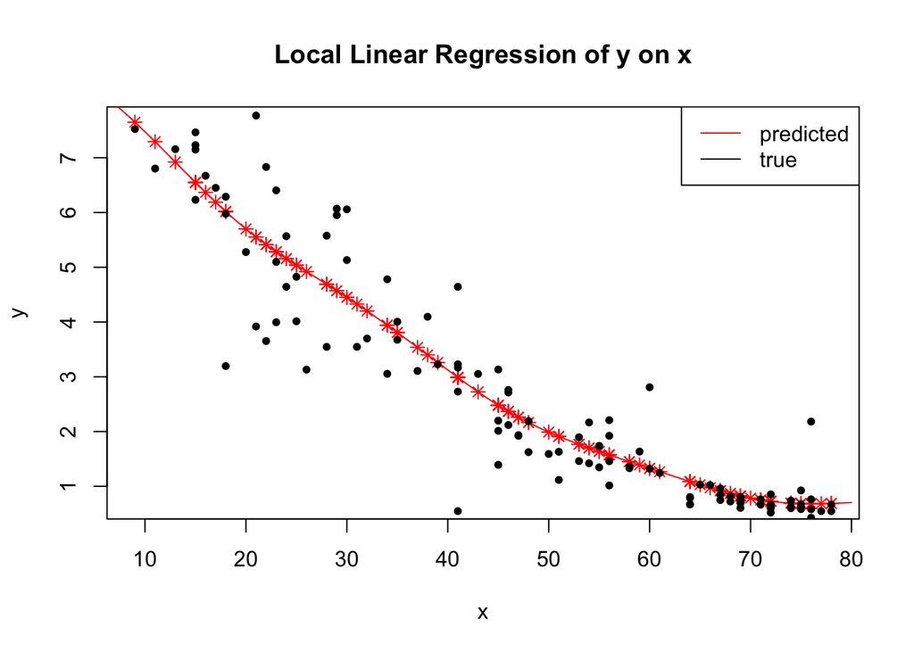

```r
#plot prediction
plot(x,y_pred,col='red',pch=8,main='Local Linear Regression of y on x',xlab='x',ylab='y')
#create a new grid for x and its predictions for plotting the line
x_new=seq(5,80,by=0.1)
y_newpred=llr$llr_all(y,x,x_new,hbest_llr_loocv)
lines(x_new,y_newpred,col='red')
points(x,y,pch=20)
legend('topright',c('predicted','true'),lty=1,col=c('red','black'))
```

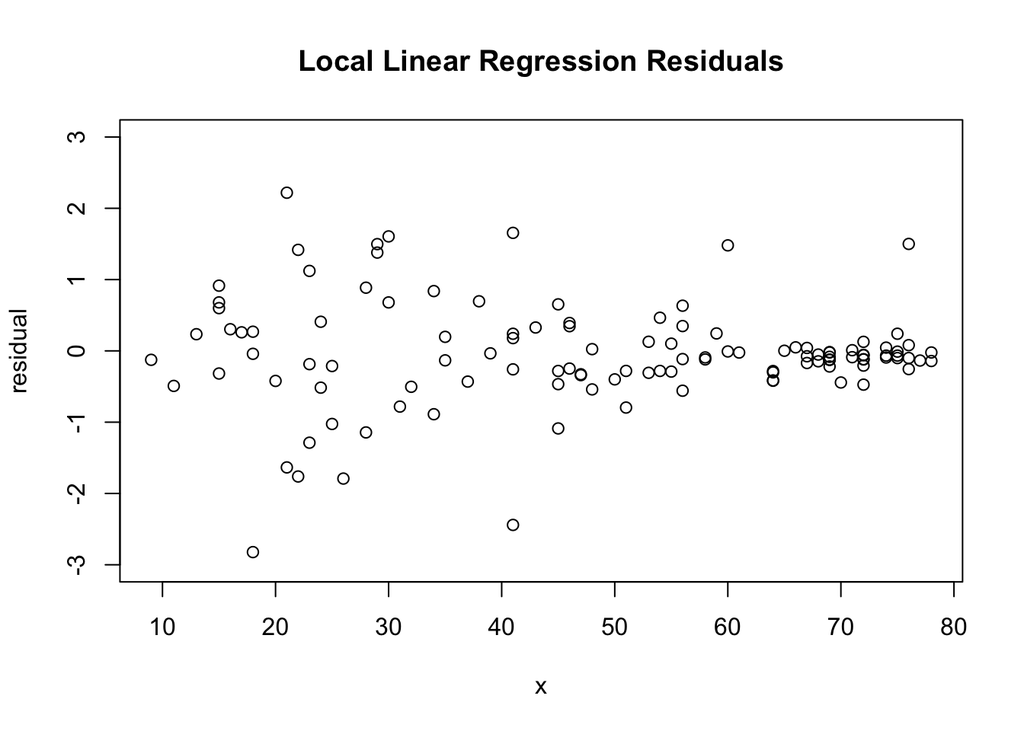

```r
#plot residuals
plot(x,y-y_pred,main='Local Linear Regression Residuals',xlab='x',ylab='residual',ylim=c(-3,3))
```

```r
#homoscesdasticity does not hold, looks like residuals get smaller when x gets bigger
#adjust the weights according to the variance
```

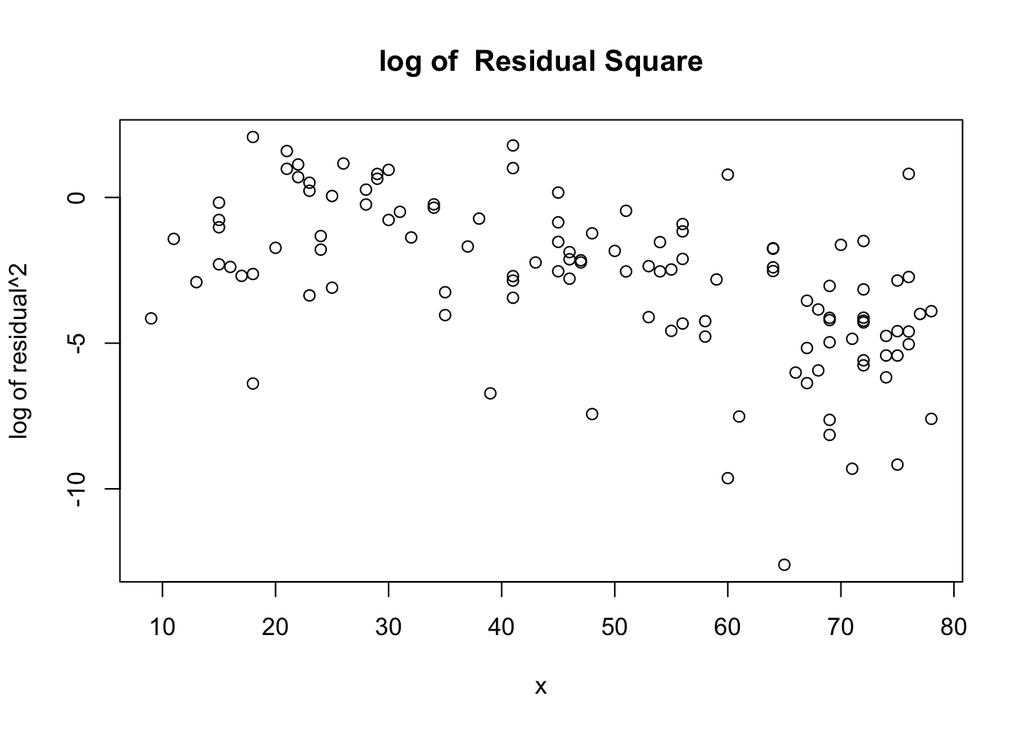

```r
#adjust the weights according to the variance
#observe the residual with respect to x
plot(x,log((y-y_pred)^2),main='log of  Residual Square',xlab='x',ylab='log of residual^2')
```

```r
# we guess a function of variance in the form of
x_qm=cbind(x,x^2)
lm_guess=lm(log((y-y_pred)^2)~x_qm)
lm_guess
```

```
##
## Call:
## lm(formula = log((y - y_pred)^2) ~ x_qm)
##
## Coefficients:
## (Intercept)        x_qmx         x_qm
##   -1.479810     0.044177    -0.001261
```

```r
#guess
a=lm_guess$coefficients[1]
b=lm_guess$coefficients[2]
c=lm_guess$coefficients[3]


llr_hetero <- module({
  import('stats')
  # calculate Kernal, input distannce and bandwidth, return kernal function value
  K <- function(d,h){
    return(dnorm(x=d/h,mean=0,sd=1))
  }
  #calculate s1 and s2
  s2 <- function(x,xi,h){
    return(sum(K(xi-x,h)*(xi-x)^2))
  }
  s1 <- function(x,xi,h){
    return(sum(K(xi-x,h)*(xi-x)))
  }
  #calculate normalized weights
  weights_hetero <- function(x,xi,h,a,b,c){
    w <- K(xi-x,h)/(exp(a+b*xi+c*xi^2)) * (s2(x,xi,h)-(xi-x)*s1(x,xi,h))
    w <- w/sum(w)
    return(w)
  }
  #calculate prediction for one single points
  llr_single_hetero <- function(y,x,xi,h,a,b,c){
    w <- weights_hetero(x,xi,h,a,b,c)
    y_pred <- t(w) %*% y
    return(y_pred)
  }
  #calculate prediction for all points
  llr_all_hetero <- function(y,x,t,h,a,b,c){
    y_pred_all=sapply(t,function(i) llr_single_hetero(y,x,i,h,a,b,c))
    return(y_pred_all)
  }
})


llr_hetero_loocv <- function(y,x,h,a,b,c){
  ypred=llr_hetero$llr_all_hetero(y,x,x,h,a,b,c)
  H= sapply(x,function(t) llr_hetero$weights_hetero(x,t,h,a,b,c))
  err <- sapply(c(1:dim(H)[1]), function(i)  ((y[i]-ypred[i])/(1-diag(H)[i]))^2  )
  return(list(ypred=ypred,err=err))
}

# choose the best h by applying loocv
llr_loocv_err_hetero=sapply(h,function(t) llr_hetero_loocv(y,x,t,a,b,c)$err)
llr_loocv_err_h_hetero=colSums(llr_loocv_err_hetero)

hbest_llr_loocv_hetero=h[which.min(llr_loocv_err_h_hetero)]
hbest_llr_loocv_hetero
```

```
## [1] 6.833333
```

```r
#plug in the best h
y_pred_hetero=llr_hetero$llr_all_hetero(y,x,x,hbest_llr_loocv_hetero,a,b,c)
head(y_pred_hetero,10)
```

```
##  [1] 4.9222837 6.0184671 5.1589377 2.9884389 2.4797174 1.3284350 0.9724587
##  [8] 0.7261017 0.7261017 1.0871194
```

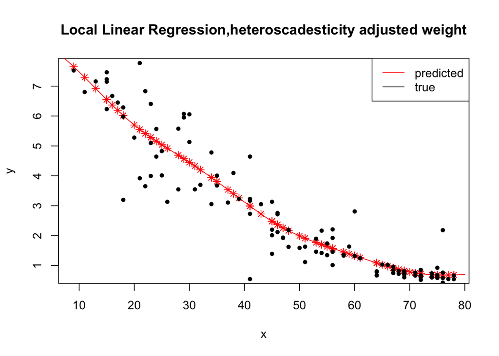

```r
#plot prediction
plot(x,y_pred_hetero,col='red',pch=8,main='Local Linear Regression,heteroscadesticity adjusted weight',xlab='x',ylab='y')
#create a new grid for x and its predictions for plotting the line
x_new=seq(5,80,by=0.1)
y_newpred_hetero=llr_hetero$llr_all_hetero(y,x,x_new,hbest_llr_loocv_hetero,a,b,c)
lines(x_new,y_newpred_hetero,col='red')
points(x,y,pch=20)
legend('topright',c('predicted','true'),lty=1,col=c('red','black'))
```

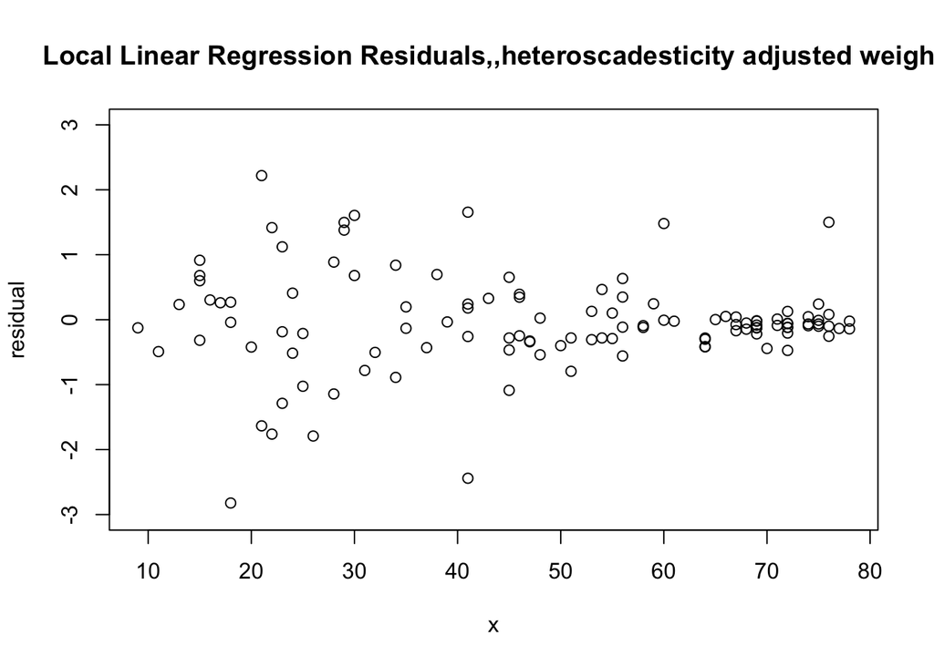

```r
#plot residuals
plot(x,y-y_pred_hetero,main='Local Linear Regression Residuals,,heteroscadesticity adjusted weight',xlab='x',ylab='residual',ylim=c(-3,3))
```

#### Part G

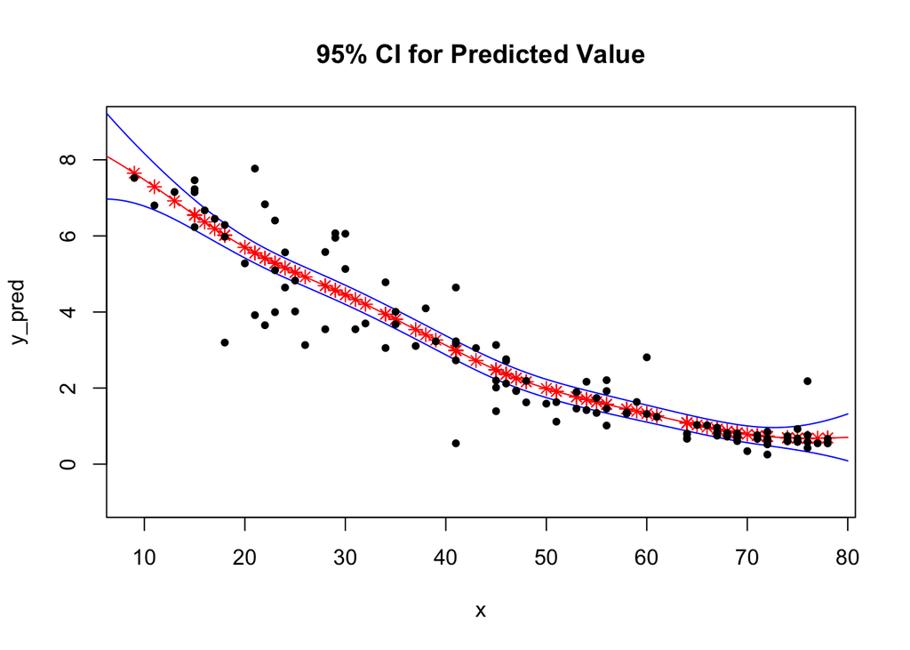

```r
#estimate sigma^2
n=length(y)
#calculate normalized weights l and its l2 norm
ls <- sapply(x, function(t) llr$weights(x,t,hbest_llr_loocv))
H=t(ls)
sig2 = sum((y-y_pred)^2)/(n-2*sum(diag(H))+sum(diag(t(H)%*%H)))
l2=sqrt(colSums(ls^2))
#var(f) is sigma^2 * ||l||_2^2
sig2f=l2^2*sig2

#gaussian 95% critical value 1.96
y_ub=y_pred+1.96*sqrt(sig2f)
y_lb=y_pred-1.96*sqrt(sig2f)

#do the same thing for the new x grid we create, to plot the line
ls_new=sapply(x_new, function(t) llr$weights(x,t,hbest_llr_loocv))
l2_new=sqrt(colSums(ls_new^2))
sig2f_new=l2_new^2*sig2
y_ub_new=y_newpred+1.96*sqrt(sig2f_new)
y_lb_new=y_newpred-1.96*sqrt(sig2f_new)

plot(x,y_pred,pch=8,col='red',main='95% CI for Predicted Value',ylim=c(-1,9))
lines(x_new,y_newpred,col='red')
#points(x,y_ub,pch=19,col='blue')
#points(x,y_lb,pch=19,col='blue')
lines(x_new,y_ub_new,col='blue')
lines(x_new,y_lb_new,col='blue')
points(x,y,pch=20)
```

## Gaussian Process

#### Part A

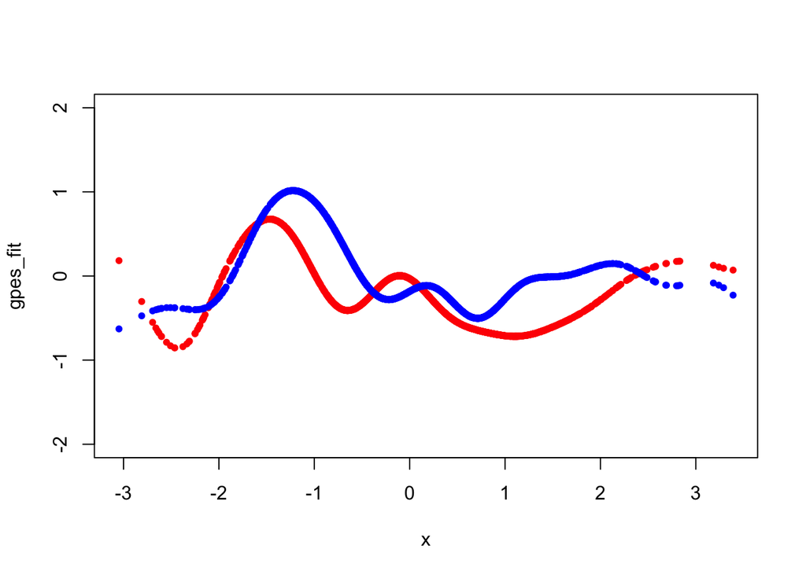

```r
library(mvtnorm)
N=2000
x <- rnorm(N,0,1)
m <- rep(0,N)

#GP of 0 mean, Sqaure exponential Covariance for unit interval
gp_es <- function(x,b,tau1sq, tau2sq){
  m <- rep(0,length(x))
  C <- matrix(0,length(x),length(x))
  for(i in 1:length(x)) {
    for(j in 1:length(x)) {
      C[i,j] <- tau1sq*exp(-0.5*{(x[i]-x[j])/b}^2) + tau2sq*(x[i]==x[j])
    }
  }
  fx=as.vector(rmvnorm(n=1,mean=m,sigma=C))
  return(fx)
}

gp_m52 <- function(x,b,tau1sq, tau2sq){
  m <- rep(0,length(x))
  C <- matrix(0,length(x),length(x))
  for(i in 1:length(x)) {
    for(j in 1:length(x)) {
      C[i,j] <- tau1sq*exp(-0.5*{(x[i]-x[j])/b}^2) + tau2sq*(x[i]==x[j])
    }
  }
  fx=as.vector(rmvnorm(n=1,mean=m,sigma=C))
  return(fx)
}

gpes_fit=gp_es(x,0.5,0.5,10^(-6))
gpm52_fit=gp_m52(x,0.5,0.5,10^(-6))

plot(x,gpes_fit,col='red',ylim=c(-2,2),pch=20)
points(x,gpm52_fit,col='blue',ylim=c(-2,2),pch=20)
```

#### Part B

$$\left(
\begin{array}{c}
f(x*) \\
f(x)
\end{array}
\right)
\sim N\left(
\left(
\begin{array}{c}
\mu^* \\
\mu
\end{array}
\right),
\left(
\begin{array}{cc}
C(x^*,x^*) & C(x^*,x) \\
C(x,x*) & C(x,x)
\end{array}
\right)
\right)$$

The $(i,j)$ entry of $C(x,x)$ is applying covariance $C$ function to $x_i$, $x_j$, i.e, $C(x_i,x_j)$.\

For the ease of notation, Call $f(x*)=f*$, $f(x)=f$.\

The conditional of $f^*|f$ is $f^*|f N(‘,’) $ where
$$\mu' =\mu^* +C(x^*,x)C(x,x)^{-1}(f-\mu)$$
$$\Sigma=C(x^*,x^*)-C(x^*,x)C(x,x)^{-1}C(x,x^*)$$

:\ We know $(f^*,f)$ is jointly normal, with density
$$p(f^*,f) \propto exp\left(-\frac{1}{2}[(f^*-\mu^*)^T,(f-\mu)^T]\Sigma^{-1}\left[\begin{array}{cc}
f^*-\mu^* \\
f-\mu
\end{array}\right]\right)$$
where
$$\Sigma=\left(
\begin{array}{cc}
C(x^*,x^*) & C(x^*,x) \\
C(x,x*) & C(x,x)
\end{array}
\right)$$
$$\Sigma^{-1}=\Omega=\left(
\begin{array}{cc}
\Omega_{11} & \Omega_{12} \\
\Omega_{21} & \Omega_{22}
\end{array}
\right)
=\left[
\begin{array}{cc}
(\Sigma_{11}-\Sigma_{12}\Sigma_{22}^{-1}\Sigma_{12}^T)^{-1} &-(\Sigma_{11}-\Sigma_{12}\Sigma_{22}^{-1}\Sigma_{12}^T)^{-1}\Sigma_{12}\Sigma_{22}^{-1}\\
-\Sigma_{22}^{-1}\Sigma_{12}^T(\Sigma_{11}-\Sigma_{12}\Sigma_{22}^{-1}\Sigma_{12}^T)^{-1} &(\Sigma_{22}-\Sigma_{12}^T\Sigma_{11}^{-1}\Sigma_{12})^{-1}
\end{array}
\right]$$

working on a log scale,
$$\log p(f^*,f) \propto -\frac{1}{2}[(f^*-\mu^*)^T,(f-\mu)^T]
\left[\begin{array}{cccc}
\Omega_{11} &\Omega_{12}\\
\Omega_{12}^T &\Omega_{22}
\end{array}\right]
\left[\begin{array}{cc}
f^*-\mu^* \\
f-\mu
\end{array}\right]$$

$$\log p(f^*,f) \propto -\frac{1}{2}\left[(f^*-f)^T\Omega_{11}(f^*-\mu^*)+2(f^*-\mu^*)^T\Omega_{12}(f-\mu)+(f-\mu)^T\Omega_{22}(f-\mu)\right]$$

We know the marginal distribution of $f$ is
$$p(f)=N(\mu,\Sigma_{22})$$
Thus
$$p(f^*|f)=\frac{p(f^*,f)}{p(f)}$$
$$\begin{align}
\log(p(f^*|f) \propto -\frac{1}{2}[&(f^*-\mu^*)^T\Omega_{11}(f^*-\mu^*)+2(f^*-\mu^*)^T\Omega_{12}(f-\mu)+(f-\mu)^T\Omega_{22}(f-\mu) \\
&-(f-\mu)^T\Sigma_{22}^{-1}(f-\mu) ])
\end{align}$$

Thus,
$$f^*-\mu^*|f \sim N(\Omega_{11}^{-1}\Omega_{12}(f-\mu),\Omega_{11}^{-1})$$
which means,
$$f^*|f \sim N(\mu^*+\Omega_{11}^{-1}\Omega_{12}(f-\mu), \Omega_{11}^{-1})$$

Plug in the expression for $\Omega$ and $\Sigma$,
$$\Omega_{11}^{-1}\Omega_{12}=\Sigma_{12}\Sigma_{22}^{-1}=C(x^*,x)C(x,x)^{-1}$$
$$\Omega_{11}^{-1}=\Sigma_{11}-\Sigma_{12}\Sigma_{22}^{-1}\Sigma_{12}^T=C(x^*,x^*)-C(x^*,x)C(x,x)^{-1}C(x,x^*)$$

Put together,
$$f^*|f \sim N(\mu^*+C(x^*,x)C(x,x)^{-1}(f-\mu),C(x^*,x^*)-C(x^*,x)C(x,x)^{-1}C(x,x^*))$$

#### Part C

$$p(y|\theta) \sim N(R\theta,\Sigma)$$
so we can write
$$y=R\theta+\epsilon$$
$$\epsilon\sim N(0,\Sigma)$$
Then the joint of $y$ and $\theta$ can be written as
$$\left(
\begin{array}{c}
y \\
\theta
\end{array}
\right)
=
\left(
\begin{array}{c}
R \\
I
\end{array}
\right)\theta+
\left(
\begin{array}{c}
I \\
0
\end{array}
\right)
\epsilon$$
Using Exercise 1 Question 1 Part 5 where we proved
$$x=Ax_1+Bx_2$$
$$x_1\sim MVN(\mu_1,\Sigma_1),x_2\sim MVN(\mu_2,\Sigma_2)$$
Then the MGF for $Y$ is:
$$\begin{align}
M_x(t) &= M_{Ax_1+Bx_2}(t)=E(e^{t^T(Ax_1+Bx_2)})\\
&= E(e^{(A^Tt)^Tx_1}e^{(B^Tt)^Tx_2})\\
&= M_{x_1}(A^T) M_{x_2}(B^T)\\
&= e^{t^TA\mu_1+\frac{1}{2}t^TA\Sigma_1A^Tt+t^TB\mu_2+\frac{1}{2}t^TB\mu_2+\frac{1}{2}t^TB\Sigma_2B^Tt}\\
&=e^{t^T(A\mu_1+B\mu_2)+\frac{1}{2}t^T(A\Sigma_1A^T+B\Sigma_2B^T)t}
\end{align}$$

Thus we have,
$$X\sim MVN(A\mu_1+B\mu_2,A\Sigma_1A^T+B\Sigma_2B^T)$$
In this case where
$$\left(
\begin{array}{c}
y \\
\theta
\end{array}
\right)=A\theta+B\epsilon$$
where
$$A=\left(
\begin{array}{c}
R \\
I
\end{array}
\right),
B=\left(
\begin{array}{c}
I \\
0
\end{array}
\right)$$
Thus,
$$\left(
\begin{array}{c}
y \\
\theta
\end{array}
\right)
\sim MVN(Am,AVA^T+B\Sigma B^T)$$